# CRD Exploration + Annotation

Author

Siddharth Reed

Published

October 19, 2026

```r
all.sample.metadata <-
    load_sample_metadata() %>%
    select(all_of(c('SampleID', RELEVANT_METADATA_COLUMNS)))
```

```r
FORCE_REDO <- FALSE
# FORCE_REDO <- TRUE
results_filter_fnc <- function(df) {
    df %>%
    filter(CPM.cutoff == '3CPM') %>%
    filter(z.score.counts) %>%
    filter(n.SVs == NUM_SVS_TO_GENERATE) %>%
    filter(SVs.included == NUM_SVS_TO_REMOVE)
}
```

Load CRD features + summary stats over OCRs per CRD

```r
all.CRD.features.df <-
    check_cached_results(
        results_file=ALL_CRD_STATS_TSV_FILEPATH,
        force_redo=FORCE_REDO,
        results_fnc=
            function() {
                list_all_results_files_in_set(set.name='CRD.stats') %>%
                results_filter_fnc() %>%
                mutate(
                    CRD.stats=
                        future_pmap(
                            .l=list(filepath),
                            .progress=TRUE,
                            .f=read_tsv,
                            show_col_types=FALSE
                        )
                ) %>%
                unnest(CRD.stats)
            }
    ) %>%
    select(
        CPM.cutoff, residual.model,
        # z.score.counts, n.SVs, SVs.included,
        is.decorate.filtered,
        AD.definition.column, sample.strategy, meanClusterSize, merging.level,
        CRDID, CRD.feature.type, CRD.feature, CRD.value
    )
```

# Total CRD Size and Coverage

Here I plot the total size and coverage of all CRDs in the genome across each set of CRDs estimated.

```r
stat.vars <-
    c(
        "CRD.length",
        "CRD.nPeaks",
        'peak.length-total'
    )
CRD.counts.df <-
    all.CRD.features.df %>%
    filter(CRD.feature %in% stat.vars) %>%
    select(-c(CRD.feature.type)) %>%
    pivot_wider(names_from=CRD.feature, values_from=CRD.value) %>%
    group_by(across(-all_of(c('CRDID', stat.vars)))) %>%
    summarize(
        .groups='drop',
        nCRDs=dplyr::n(),
        CRD.length=sum(CRD.length),
        CRD.nPeaks=sum(CRD.nPeaks),
        `peak.length-total`=sum(`peak.length-total`)
    ) %>%
    mutate(
        CRD.density=1e6 * CRD.nPeaks / CRD.length,
        CRD.peak.coverage=100 * `peak.length-total` / CRD.length
    ) %>%
    pivot_longer(
        all_of(c(stat.vars, 'nCRDs', 'CRD.density', 'CRD.peak.coverage')),
        names_to='CRD.feature',
        values_to='CRD.value'
    )
```

**3CPM**

**KeepDxAge**

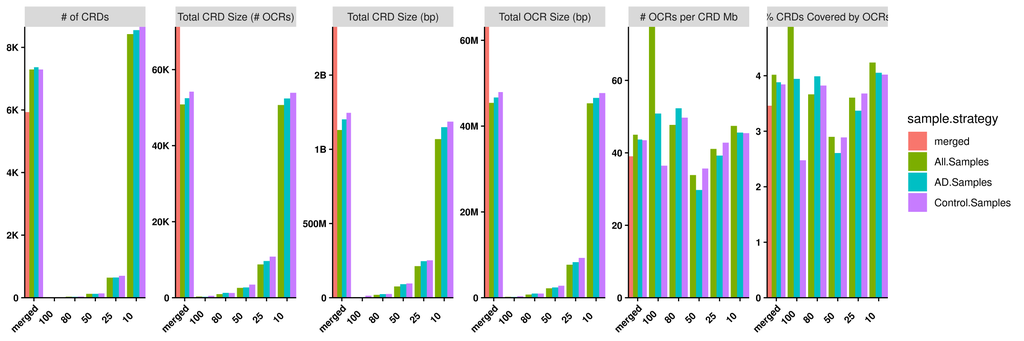

**KeepDx**

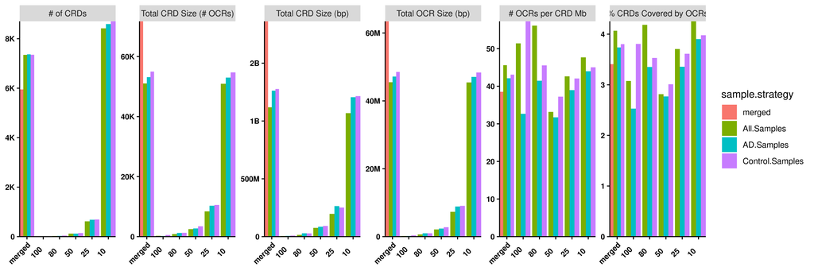

# Compare Summary Stats over OCRs per peak pre/post merging

Now we can plot summary statistics across OCRs per CRD. So for each CRD, compute statistics over OCR features (e.g. mean peak length (in bp)), then plot the distribution of this summary statistic across all CRDs for each feature.

## OCR Features

These features are related to OCR size and the size of the linked gene.

```r
OCR.summary.stats.df <-
    all.CRD.features.df %>%
    filter(CRD.feature.type %in% c('CRD.stats', 'peak.summary.stats')) %>%
    separate_wider_delim(
        CRD.feature,
        delim='-',
        names=c('feature', 'summary.stat'),
        # too_few='align_end'
        too_few='align_start'
    ) %>%
    mutate(summary.stat=ifelse(is.na(summary.stat), 'Size', summary.stat)) %>%
    # mutate(feature=ifelse(is.na(feature), 'Size', feature)) %>%
    filter(summary.stat != 'sd')
```

**3CPM**

**KeepDxAge**

**CRD.length**

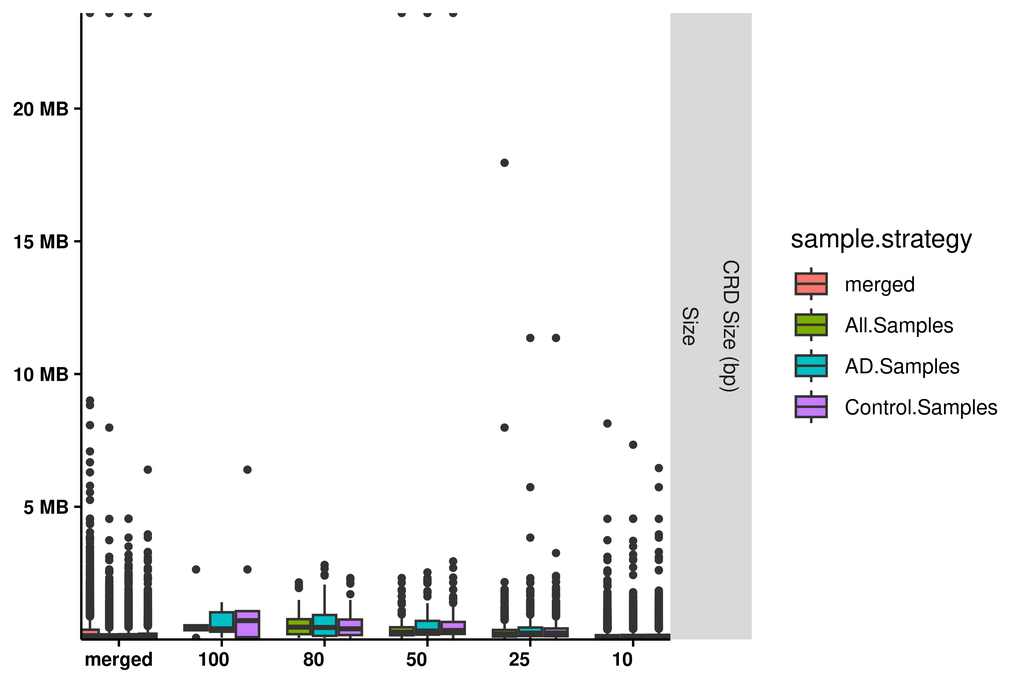

**CRD.nPeaks**

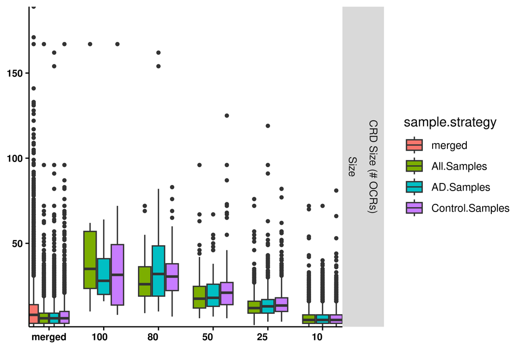

**CRD.peak.coverage**

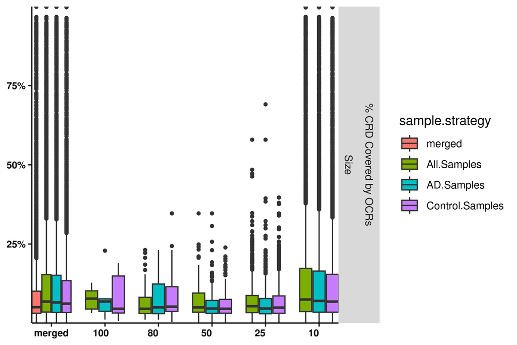

**CRD.density**

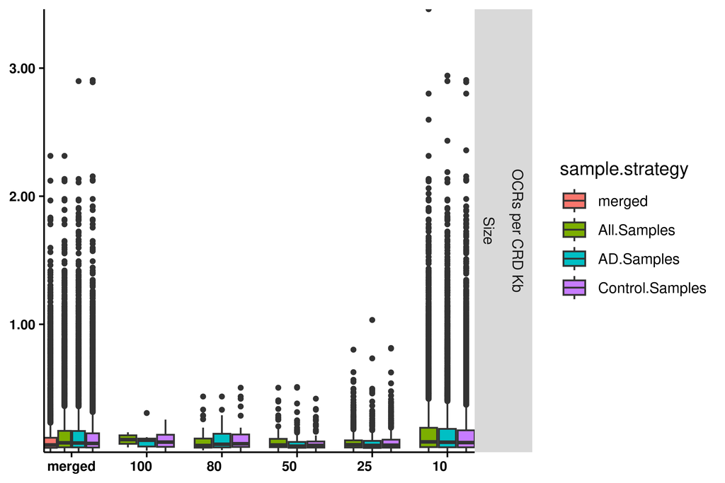

**peak.length**

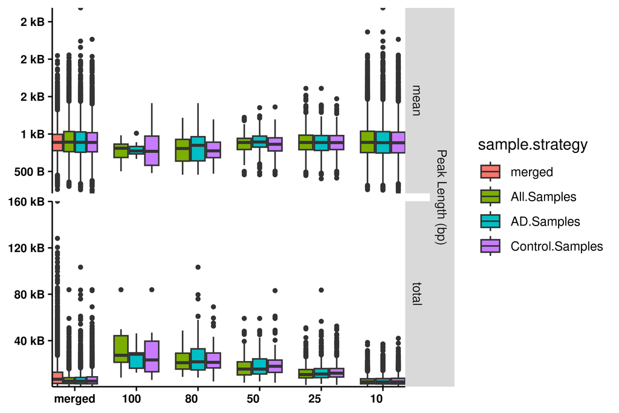

**gene.length**

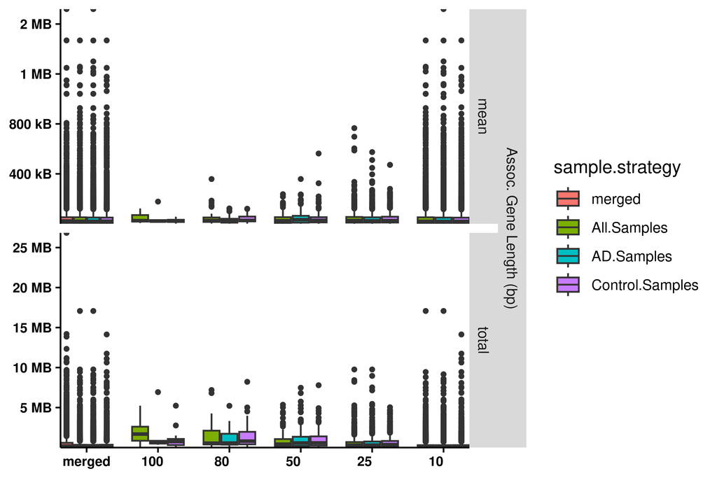

**peak.distanceToTSS**

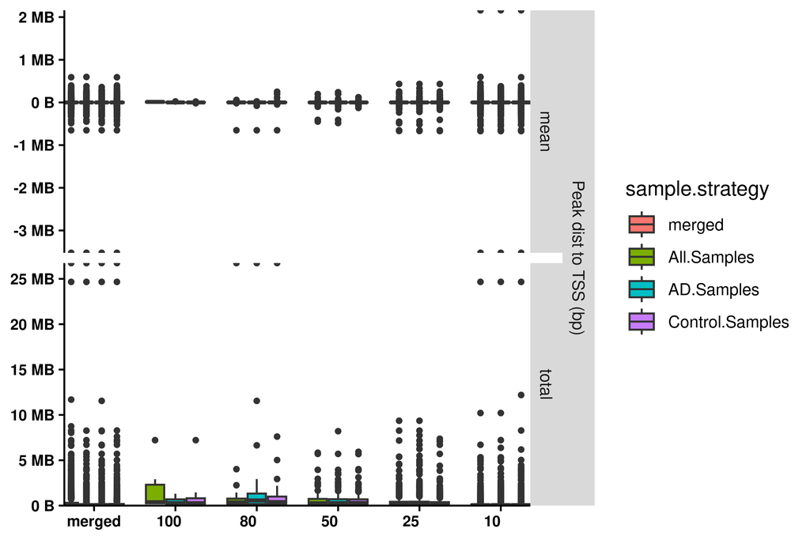

**KeepDx**

**CRD.length**

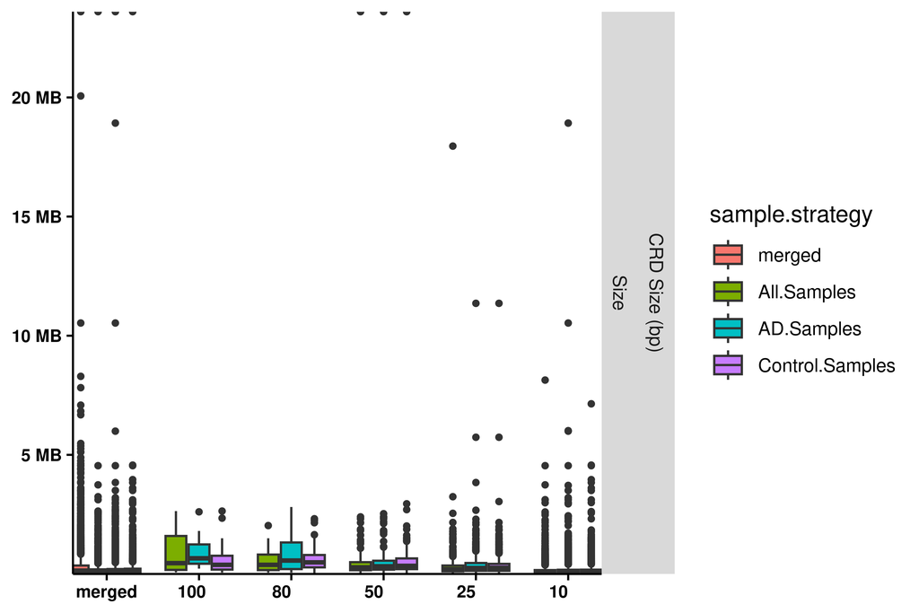

**CRD.nPeaks**

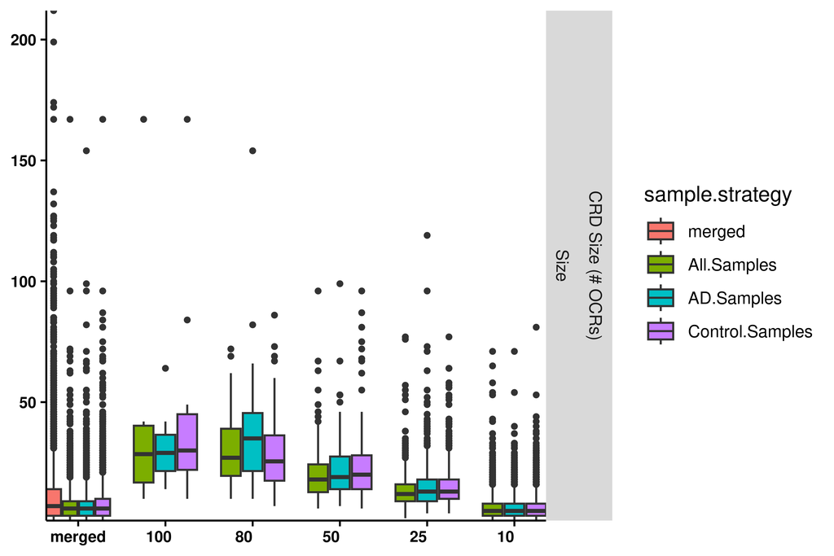

**CRD.peak.coverage**

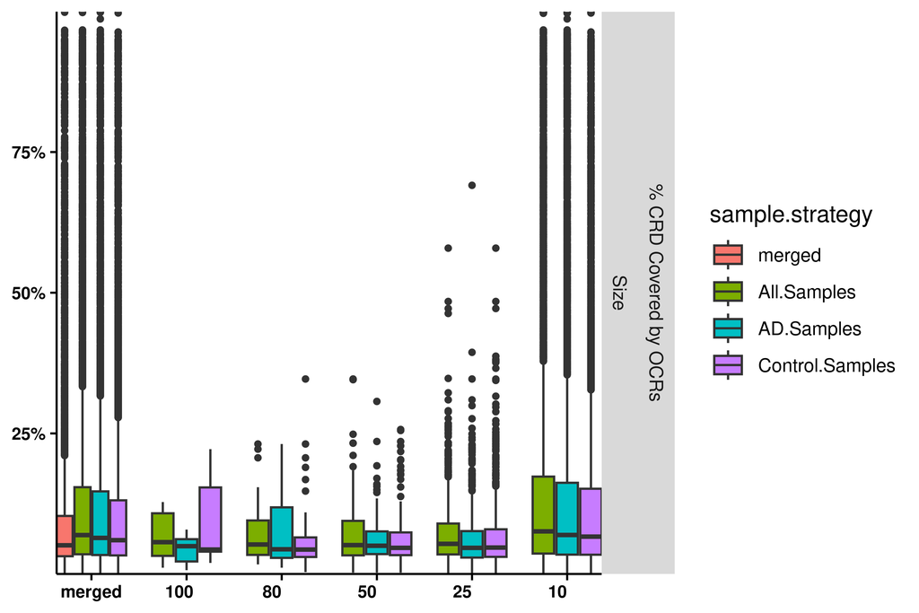

**CRD.density**

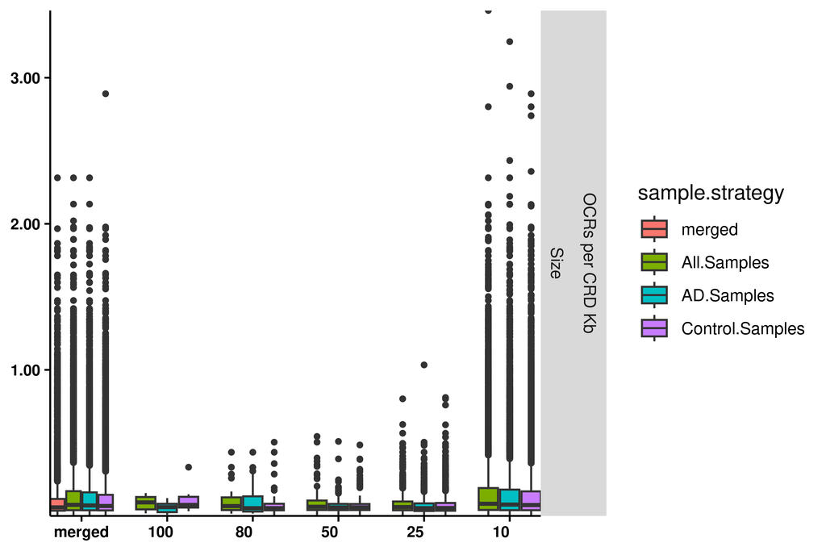

**peak.length**

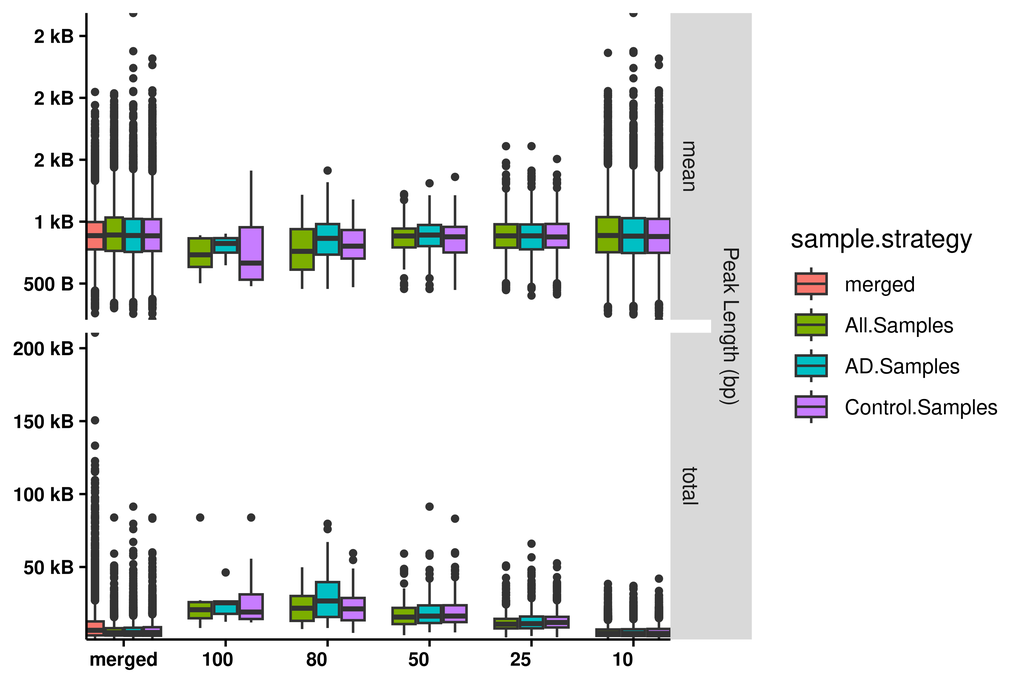

**gene.length**

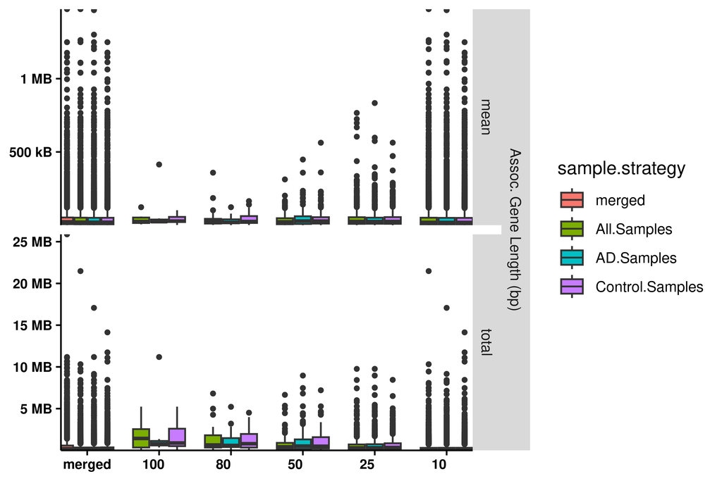

**peak.distanceToTSS**

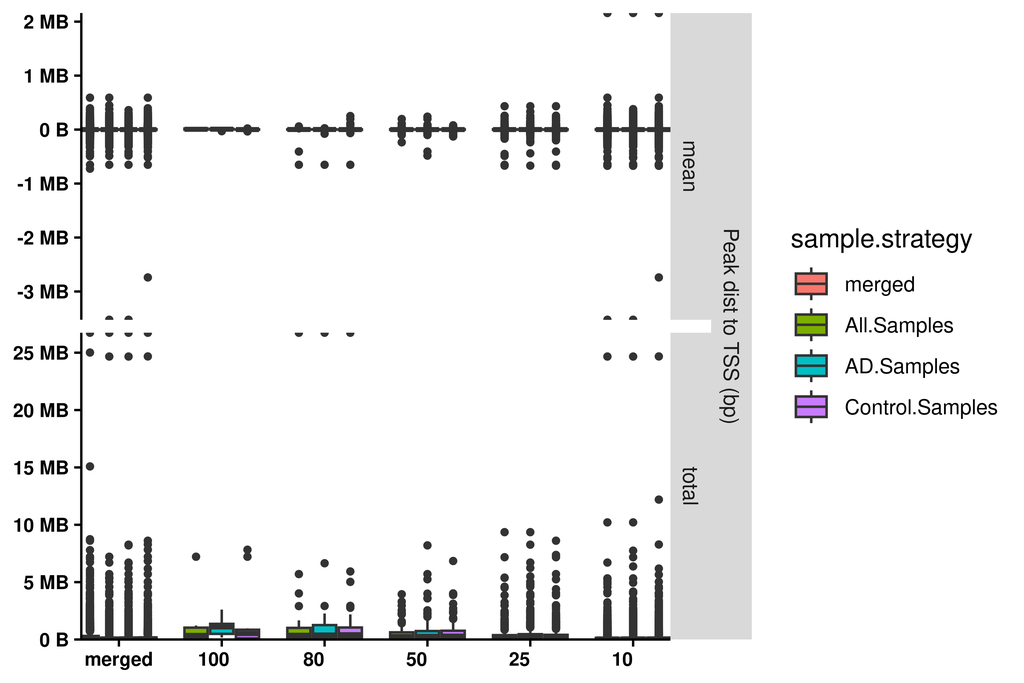

## OCR Types Frequencies per CRD

Each OCR is annotated as a specific type, so for each CRD we compute the relative abundance of each peak type e.g. promoter vs enhancer.  
Then for each category, we can plot the distribution of frequencies across all CRDs.

```r
CRD.annotation.frequencies.df <-
    all.CRD.features.df %>%
    filter(CRD.feature.type == 'peak.frequencies') %>%
    separate_wider_delim(
        CRD.feature,
        delim='-',
        names=c('peak.annotation.type', 'peak.annotation', 'metric')
    ) %>%
    filter(!(peak.annotation.type == 'merge.groups' & meanClusterSize != 'merged')) %>%
    mutate(
        metric=
            case_when(
                metric == 'n'    ~ '# of Peaks in CRD',
                metric == 'freq' ~ '% of Peaks in CRD',
            )
    )
```

**3CPM**

**KeepDxAge**

**peak.type**

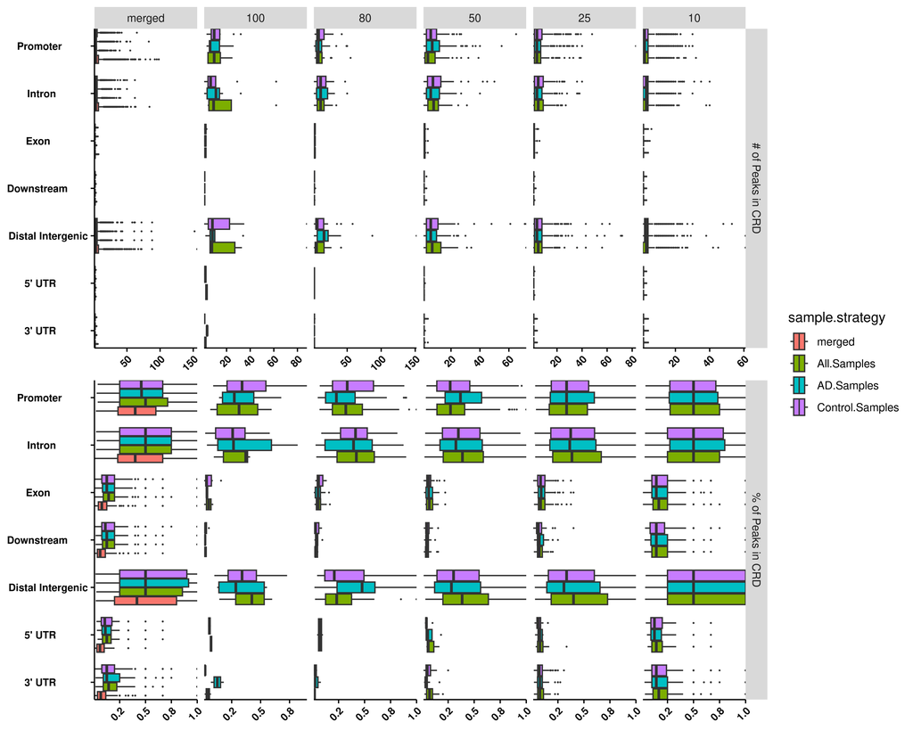

**gene.type**

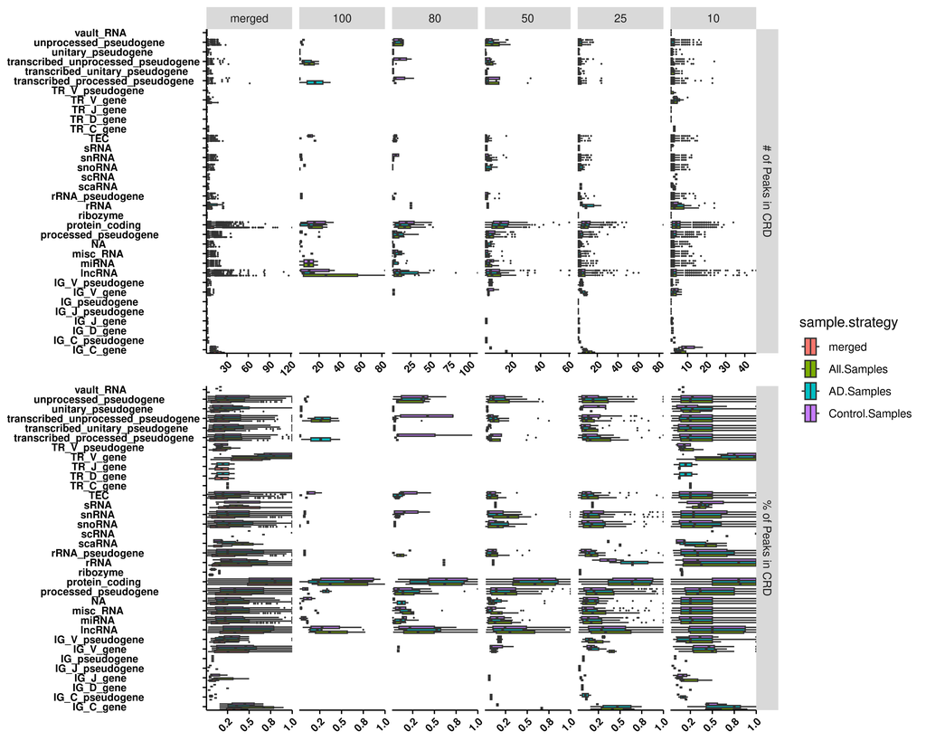

**merge.groups**

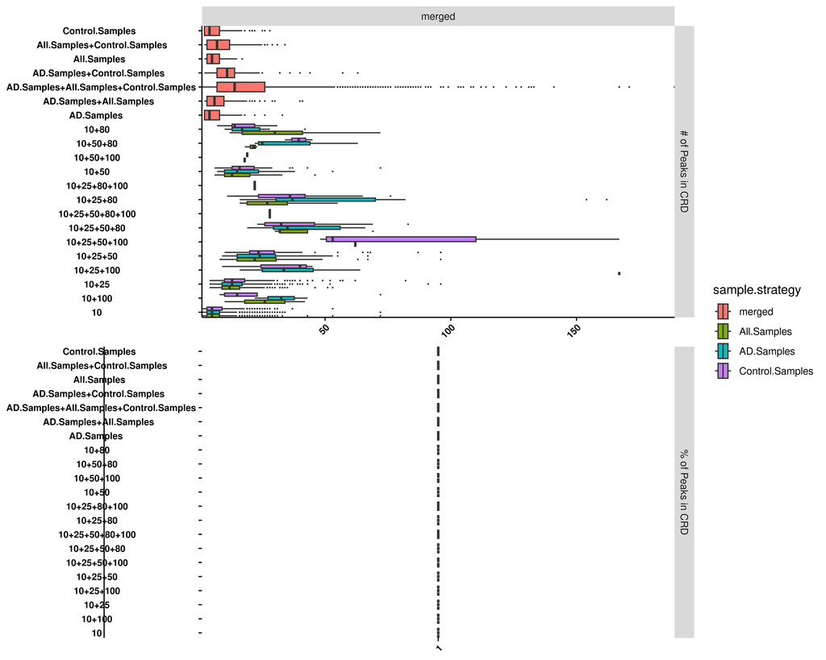

**KeepDx**

**peak.type**

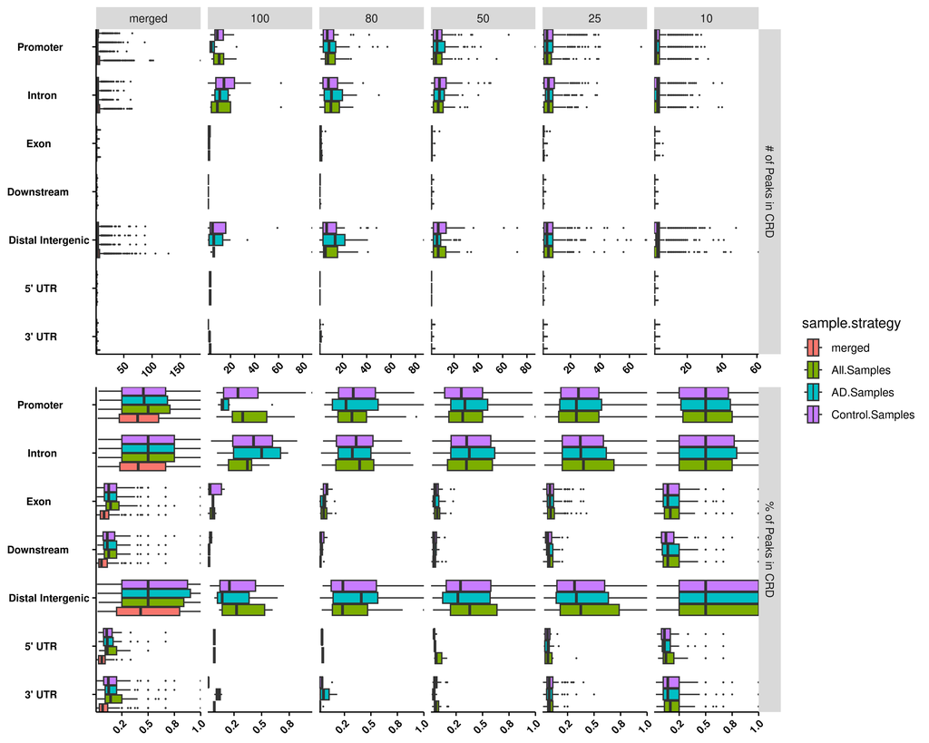

**gene.type**

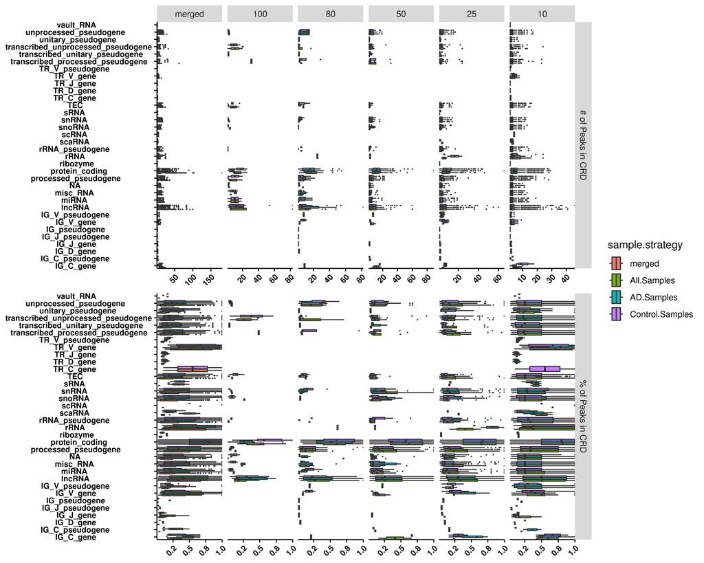

**merge.groups**

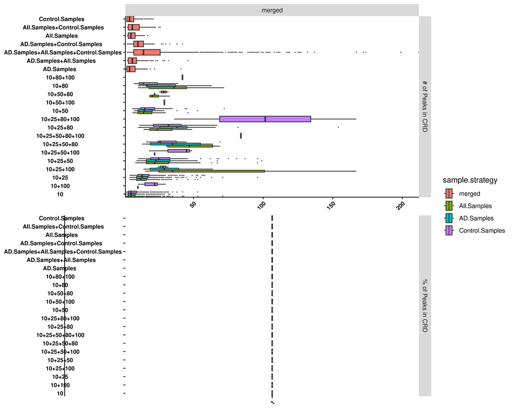

## OCR Differential statistics

For each OCR + each contrast we have the differential OCR statistics i.e. logFC + p.adjust. Again we compute summary statistics for these metrics for each CRD separately, across all OCRs in the CRD. Then we plot the distribution of these summary statistics across all CRDs.

```r
all.CRD.differential.stats.df <-
    all.CRD.features.df %>%
    filter(CRD.feature.type == 'peak.differential.stats') %>%
    separate_wider_delim(
        CRD.feature,
        delim='-',
        names=c('contrast', 'metric', 'summary.stat')
    ) %>%
    filter(summary.stat != 'sd')
```

**3CPM**

**KeepDxAge**

**AD_CERAD_withDLB**

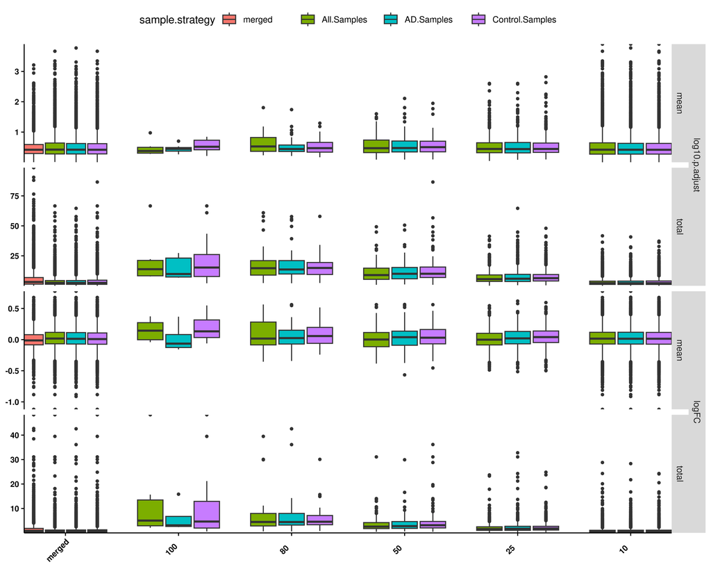

**ApoE4count_2levels**

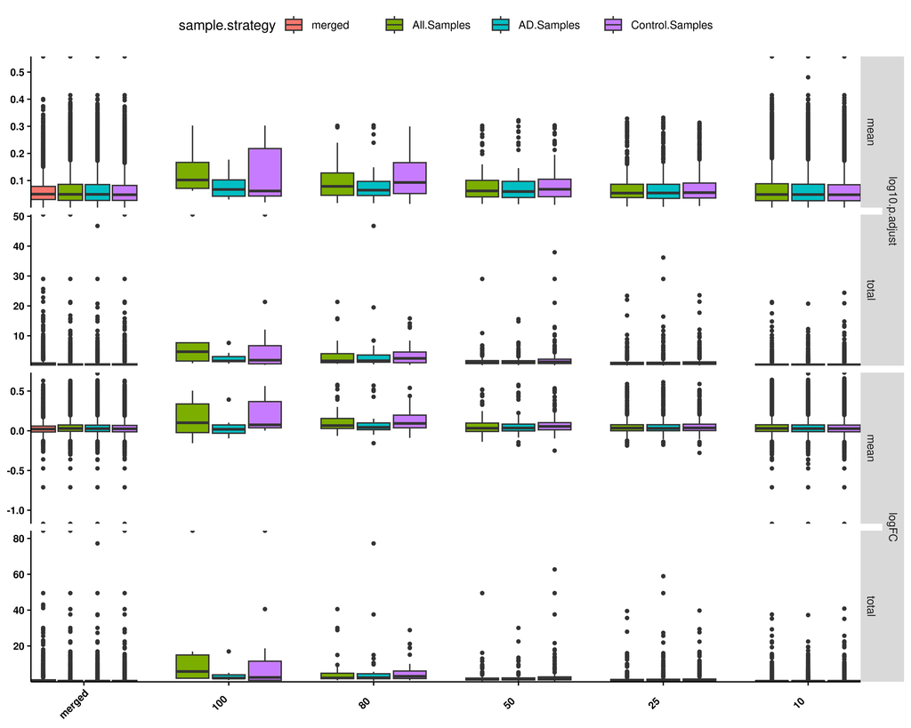

**Braak_3levels**

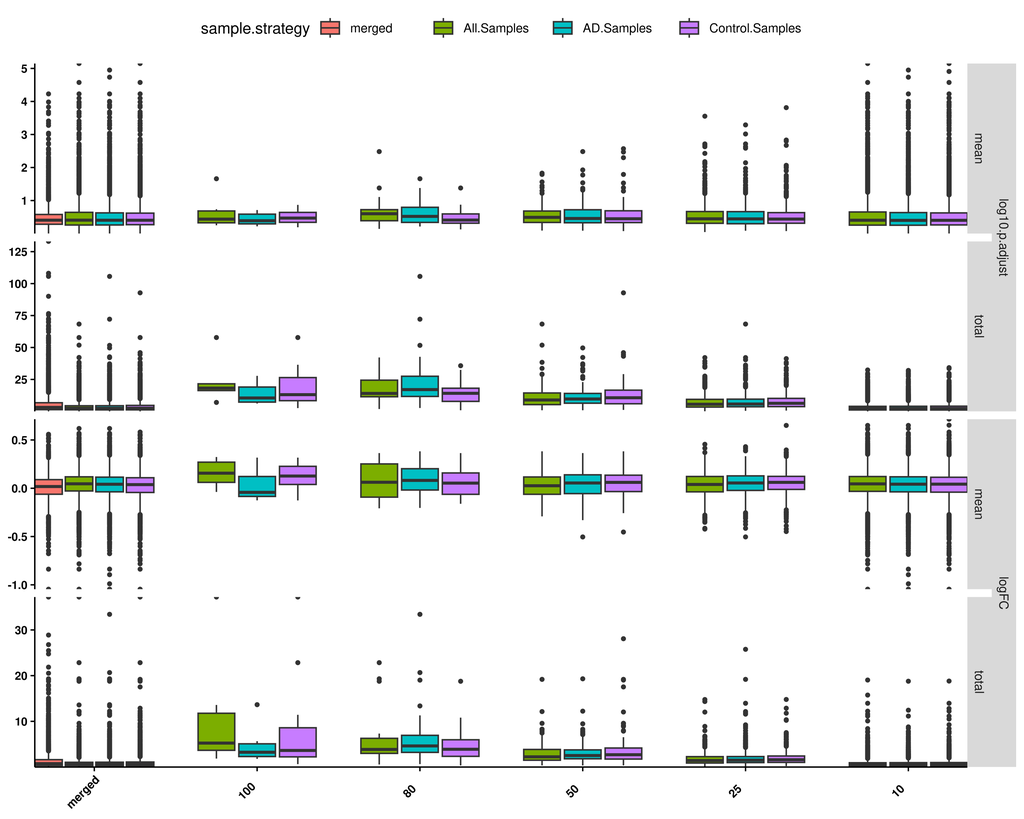

**CDR_3levels**

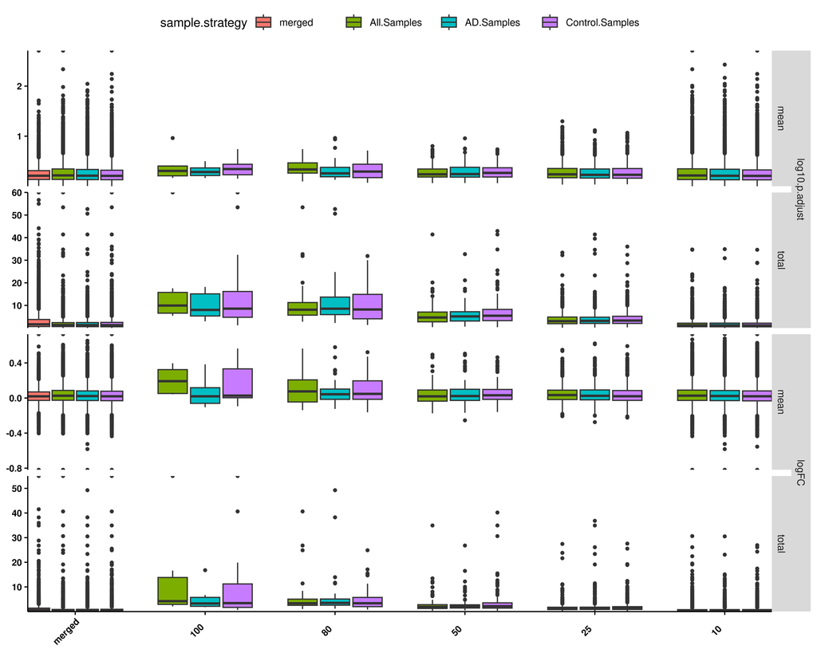

**KeepDx**

**AD_CERAD_withDLB**

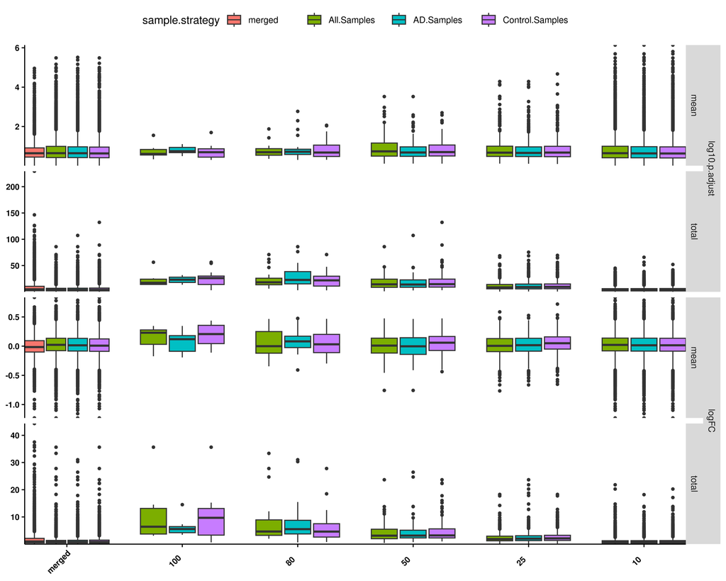

**ApoE4count_2levels**

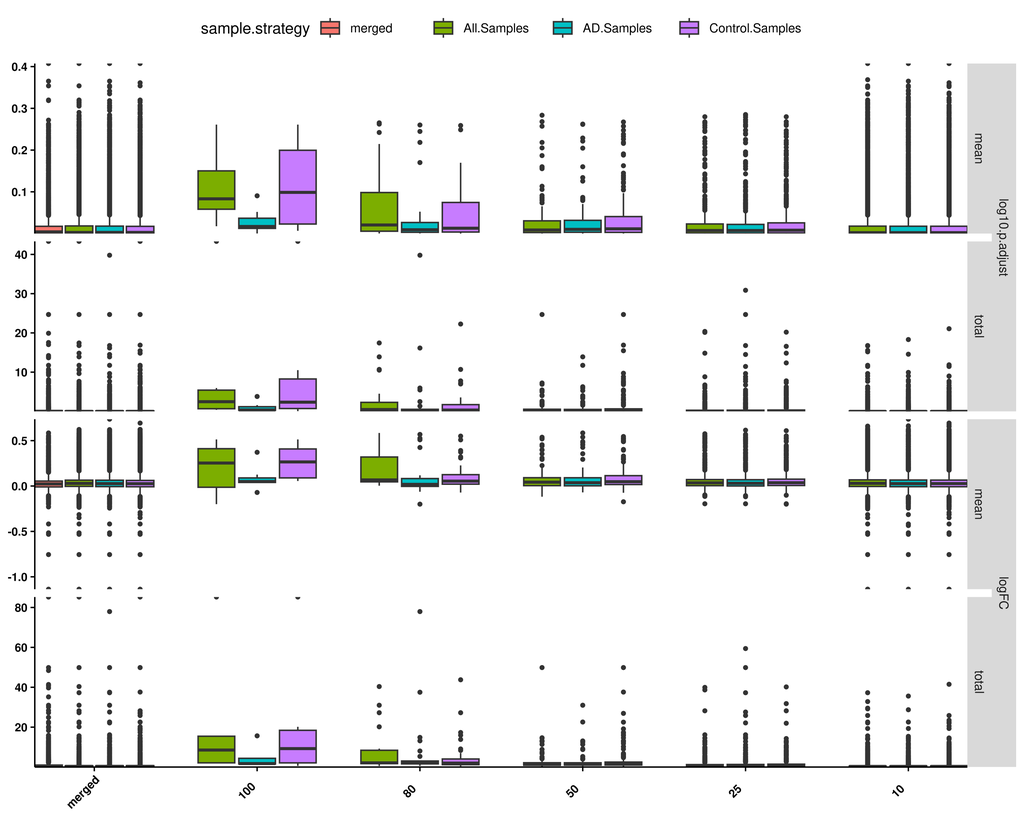

**Braak_3levels**

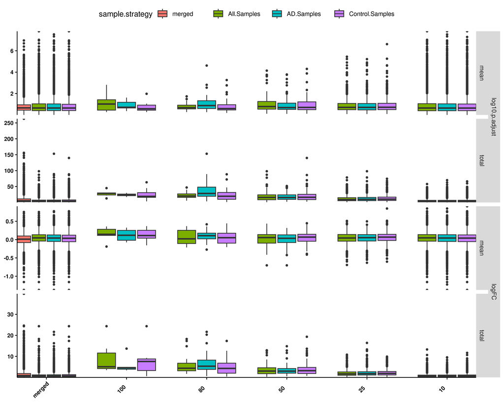

**CDR_3levels**

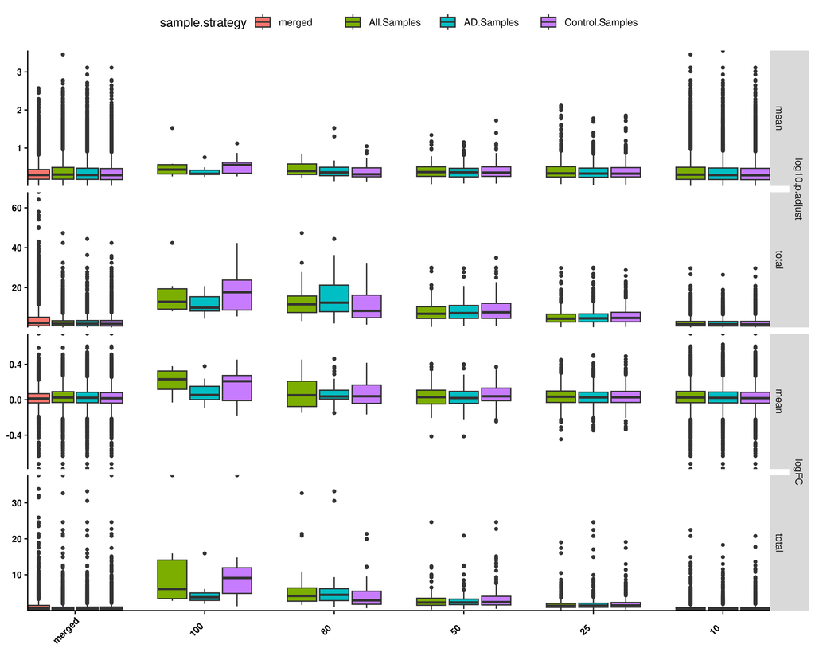